# Development of an intertidal foraminifera training set for the North Sea and an assessment of its application for Holocene sea-level reconstructions

Author: Dr. Graham Rush

Date Created: 2021-08-25

Copyright (c) Graham Rush, 2021

Email: G.Rush@leeds.ac.uk

The code is run in R 4.4.1

This is the R code to accompany the journal article: “Development of an intertidal foraminifera training set for the North Sea and an assessment of its application for Holocene sea-level reconstructions” by Rush et al. 2021 published in Marine Micropalentology. https://doi.org/10.1016/j.marmicro.2021.102055

The code, functions and data are provided are available to download on Figshare: https://figshare.com/authors/Graham_Rush/11546401

If you use any of this code please reference the article above and any incorporated packages.

The code is provided as a guide for carrying out an assessment of the most appropriate transfer function and training set to use. In order to assess different regions you will need to run the code multiple times. The core data provided is synthetic data and not intended for further analysis beyond this example.

If you try to run the code on your own data please contact me if you come across any problems.

## R code

### Set up the workspace

Set up the workspace by clearing it and linking to our data files

```r
rm(list = ls())
options(scipen = 6, digits = 4) # I prefer to view outputs in non-scientific notation
```

Set to the directory that you saved the download

```r
# wd <- paste("Your working directory")
# setwd(wd)
```

Load up the packages we will need

```r
library(rioja)
library(RColorBrewer)
library(viridis)
library(palaeoSig)
library(vegan)
library(fpc)
library(cluster)
library(dplyr)
library(plyr)
```

Load up Grahams functions into memory. These have been written by Graham Rush and incorporate functions written in the above packages. Refer to the individual functions for details.

```r
setwd(paste(wd, "/functions", sep = ""))
sapply(list.files(pattern = "[.]R$", recursive = TRUE), source) # loads all the functions in the functions folder
setwd(wd)
```

Read in the raw data Note: the core data is not provided as part of this data

```r
mod_data <- read.csv("data/northsea_forams.csv", row.names ="ID", check.names = FALSE)    # read in the full training set
core_data <- read.csv("data/Ythan-core.csv")     # read in the core data
```

Set-up and clean the data. This creates a list with colours and names to help with the plotting and analysis later and to add the cleaned data to

```r
training_sets <- list()    # create a list to store the sub-regional training sets in

## set up the colours
training_sets$cols$northsea <- viridis(9, alpha = 1) # for viridis colours
training_sets$cols$northsea <- c("#999999", "#F0E442", "#0072B2", "#E69F00", "#009E73", "#56B4E9", "#D55E00", "#CC79A7", "#000000") # for colourblind safe palette
training_sets$cols$west <- training_sets$cols$northsea[c(1:3, 7:9)]
training_sets$cols$northwest <- training_sets$cols$northsea[c(1,3,9)]
training_sets$cols$southwest <- training_sets$cols$northsea[c(2,7,8)]
training_sets$cols$east <- training_sets$cols$northsea[c(4:6)]
training_sets$cols$ythan <- training_sets$cols$northsea[c(9)]

## set up the labels
training_sets$names$northsea <- c("Alnmouth","Brancaster","Cowpen","Kjelst", "Rantum", "Sonderho", "Thornham","Welwick","Ythan")
training_sets$names$west <- training_sets$names$northsea[c(1:3, 7:9)]
training_sets$names$northwest <- training_sets$names$northsea[c(1,3,9)]
training_sets$names$southwest <- training_sets$names$northsea[c(2,7,8)]
training_sets$names$east <- training_sets$names$northsea[c(4:6)]
training_sets$names$ythan <- training_sets$names$northsea[c(9)]
```

Run grahams function in ‘clean_regions.R’ and ‘cleaning.R’ to clean the data ‘clean_data’ and remove samples with counts less than ‘min.count’ with the option to remove rare taxa (< 5 % in no more tha 1 % of the samples)

```r
training_sets$data <- clean_regions(n = 50, rare_species = FALSE, save_file = FALSE)
```

To avoid setting up and cleaning the data each time save the data using the below code and read it in and prevent re-running the above chunk use the following code

```r
save(training_sets, file="data/training_sets.RData")    # save the data
load("data/training_sets.RData")    # this line can be run to load the saved data
```

### Set the workspace for each training set

Set up the data ready to analyse training sets and transfer functions. Set the region ‘reg’ to the region of choice. You will need to repeat the code from here on for the different regions

```r
reg <- "West"     # set this to the region of choice
training.set <- training_sets$data$west    # set this to the region of choice
name <- training_sets$names$west    # set this to the region of choice

colr <- training_sets$cols$northsea
training.set$Site <- as.factor(training.set$Site)
ts.sp <- ncol(training.set)
df <- df.split(training.set, ts.sp)
env$colour <- colr[env$Site]
```

Test whether to add extra components by running a WAPLS transfer function

```r
fit.wapls <- WAPLS(spec, env$SWLI)
cv.loo <- crossval(fit.wapls, cv.method = "boot", nboot = 1000)
```

Show the outcome to test whether a significant improvement occurs to justify choosing more than one component. An increase of > 5% should occur with a p value < 0.05

```r
rand.t.test(cv.loo)
```

```
##         RMSE     R2 Avg.Bias Max.Bias Skill delta.RMSE     p
## Comp01 18.70 0.6332 -0.01866    62.58 63.32    -38.622 0.001
## Comp02 17.76 0.6847  0.22092    61.92 68.34     -5.049 0.014
## Comp03 17.32 0.7301  0.36742    53.29 72.83     -2.476 0.025
## Comp04 17.51 0.7393  0.44283    47.76 73.66      1.125 0.249
## Comp05 18.28 0.7379  0.80947    43.09 73.12      4.369 0.695
```

Adjust the number of desired components and create a label for later

```r
wapls.mod <- 2     # adjust this to fit the best choice of components
main1 = paste("WAPLS Component", wapls.mod, " ")
```

## Analysis of training set

### Plot species optimas

Use grahams functions in plot_optimas to plot the species tolerances

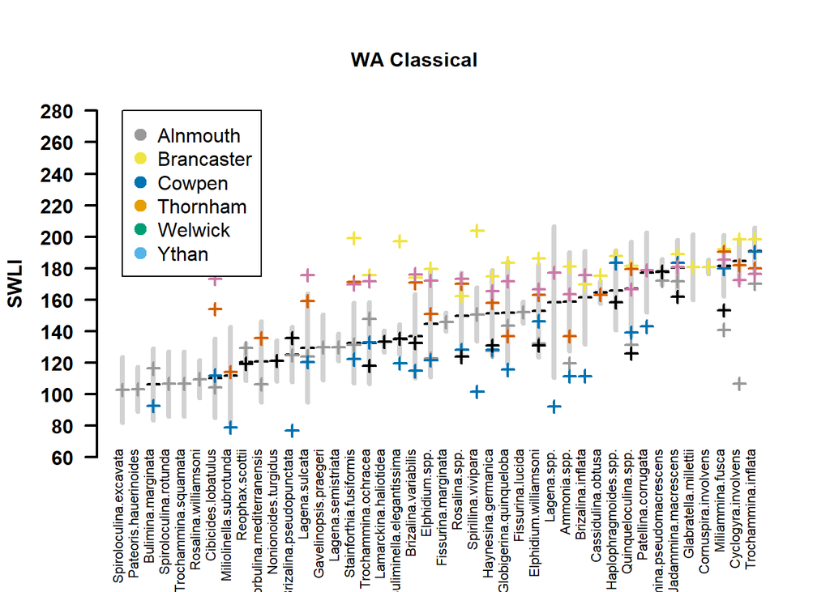

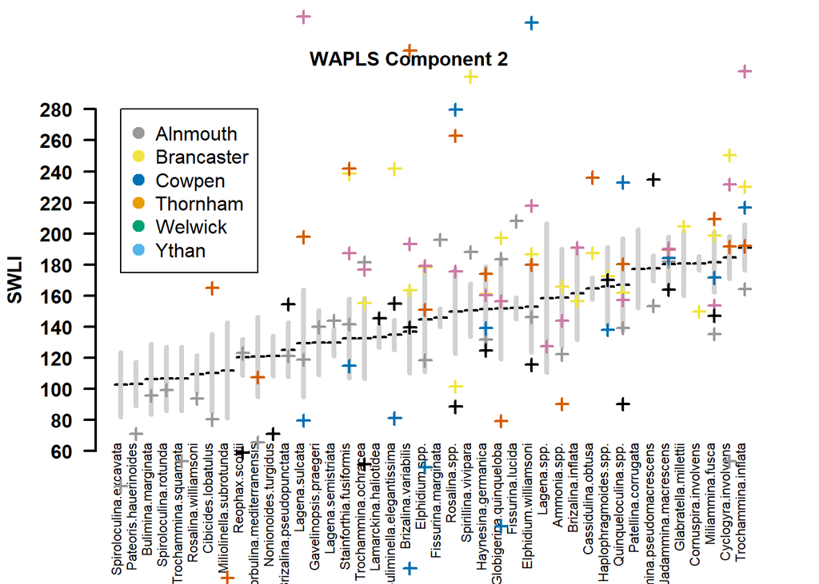

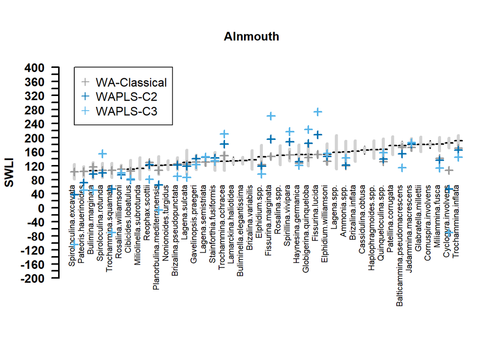

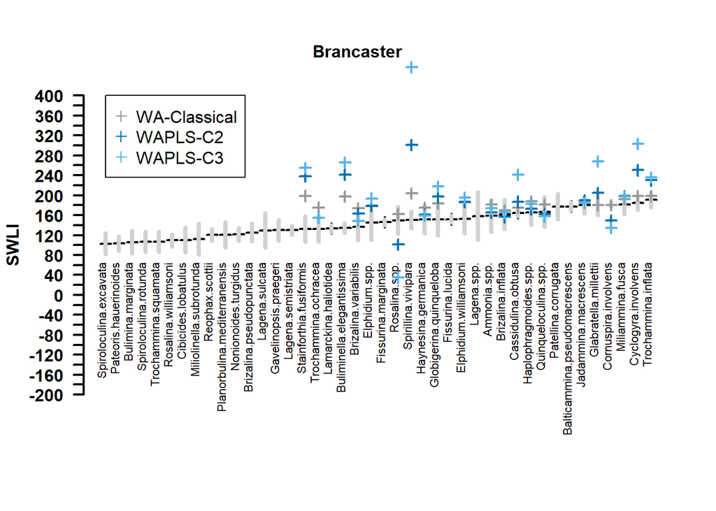

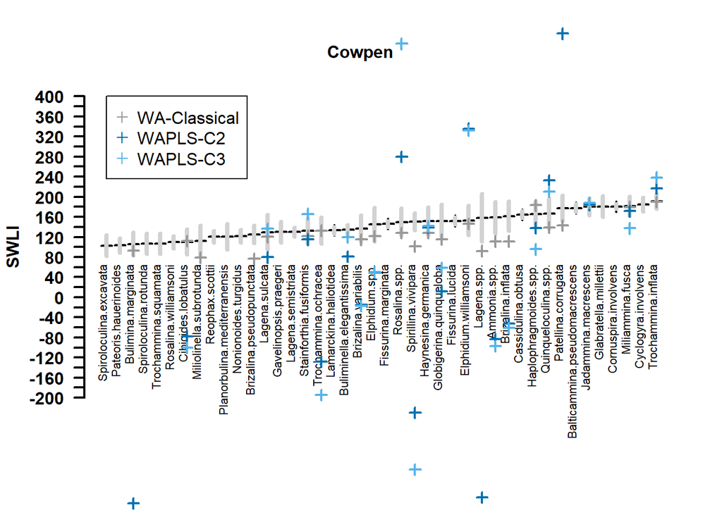

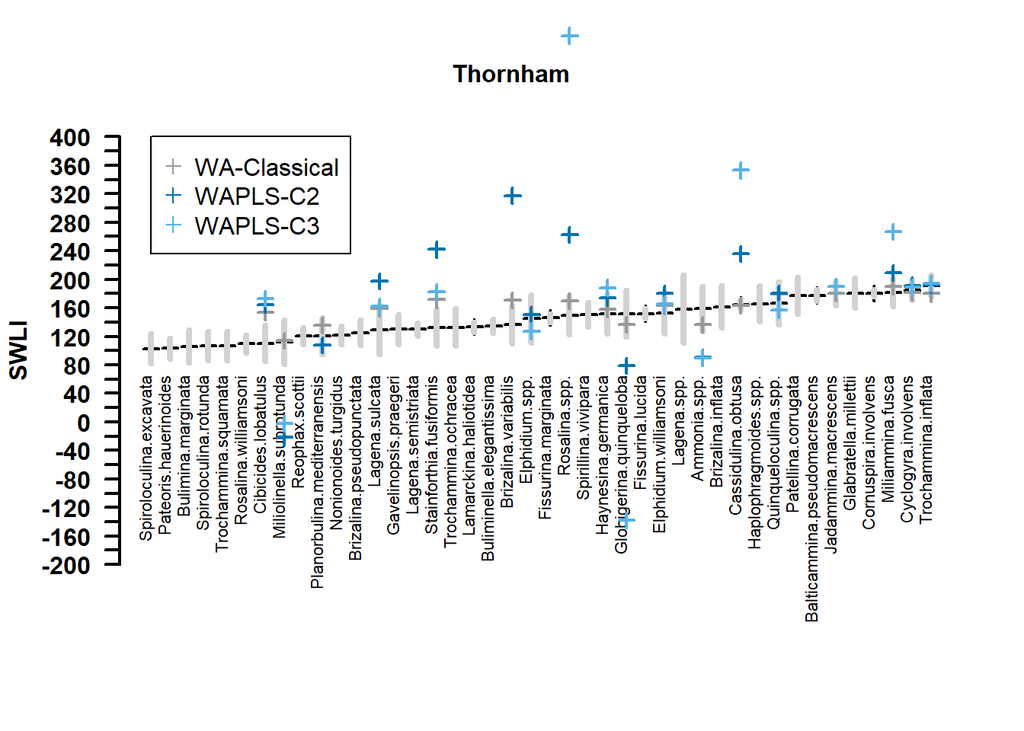

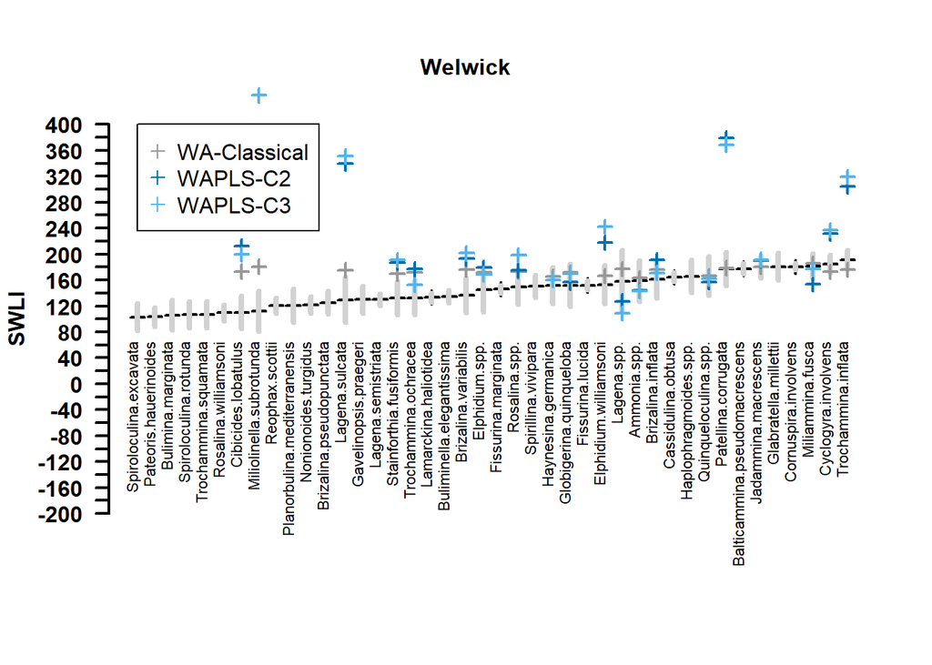

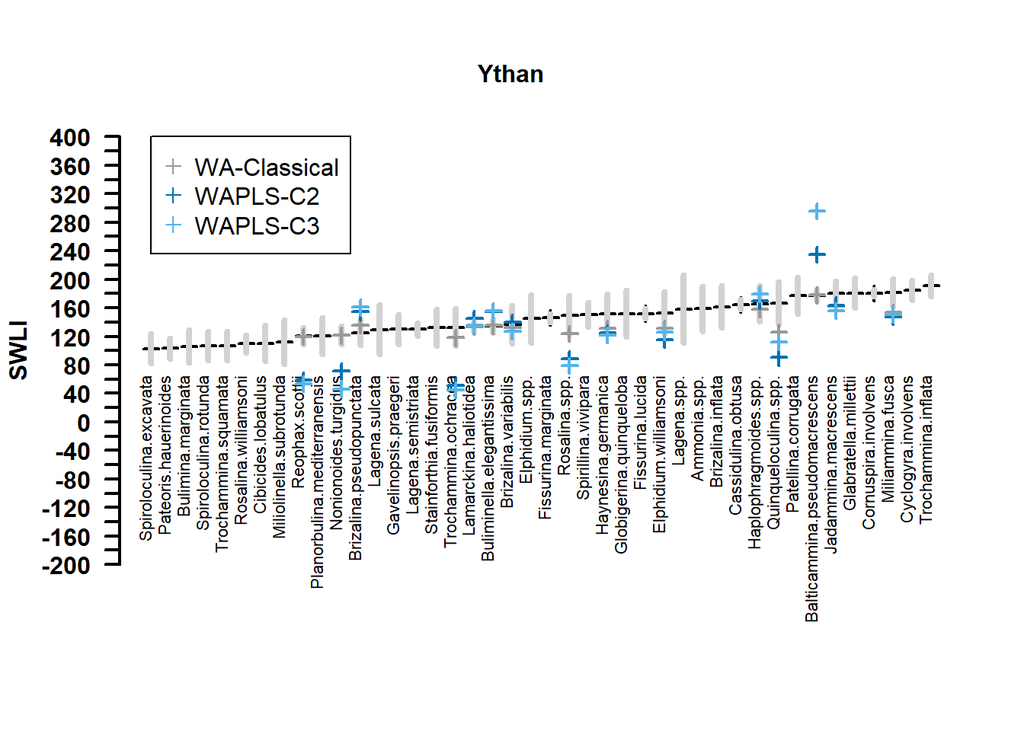

```r
plot_species_tolerances(model = 2, y_0 = 60, y_1 = 280, x_1 = ncol(spec), wa = TRUE, wapls = TRUE, component = 2, individual = TRUE)
```

### Cluster Analysis

Run the cluster analysis

```r
df.split (training.set, ts.sp)    # split the data
dis <- vegdist(spec, "euclidean")    #  set distance based on rule. Set this e.g. "bray" is bray curtis
clusters <- pamk(dis, krange = 1:10, criterion = "multiasw", critout = TRUE, metric = "euclidean")    # Test the suggested number of clusters. krange sets the number of clusters to be tested. critout prints all of the results
```

```
## 1  clusters  0
## 2  clusters  0.4669
## 3  clusters  0.3121
## 4  clusters  0.323
## 5  clusters  0.2955
## 6  clusters  0.2551
## 7  clusters  0.3204
## 8  clusters  0.2561
## 9  clusters  0.2753
## 10  clusters  0.245
```

Plot the clusters in a broken hockey stick using grahams function ‘pam_hockey_stick.R’

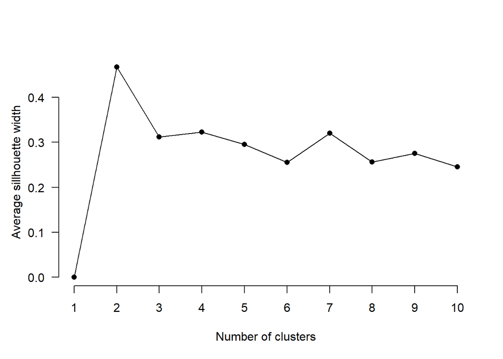

```r
pam_hockey_stick()     # uses grahams functions in pam_hockey_stick to plot broken stick graph to assess the most appropriate
```

Set to the desired number of clusters and plot the clusters using grahams functions in ‘plot_pam.R’. Four plots are produde: 1. A silhouette plot, 2. The samples goruped by cluster, plotted against SWLI and coloured by SWLI, 3. The samples goruped by cluster, plotted against SWLI and coloured by site. 4. Boxplot of the clusters against SWLI.

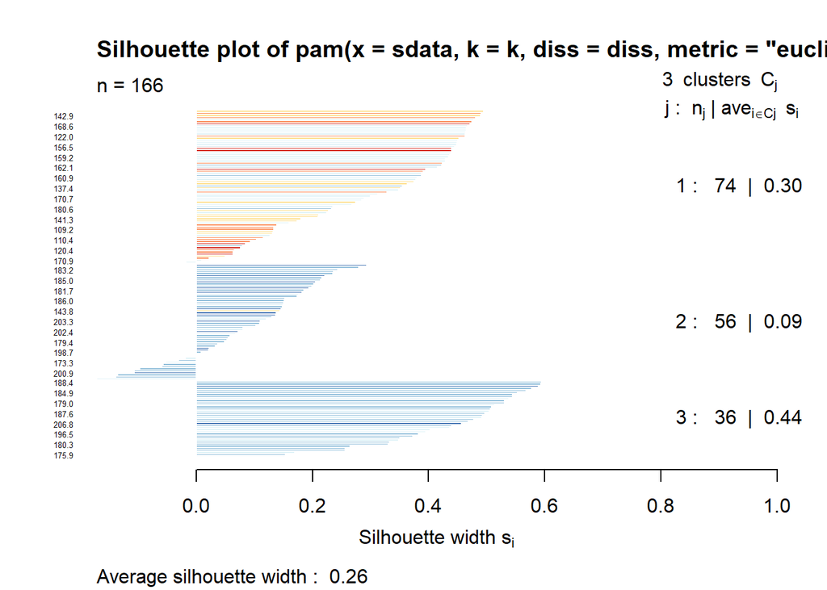

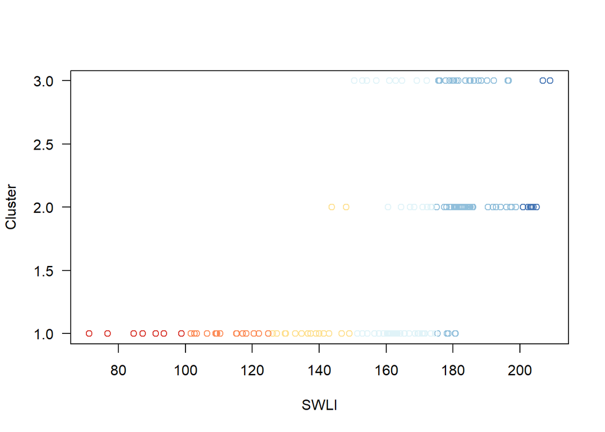

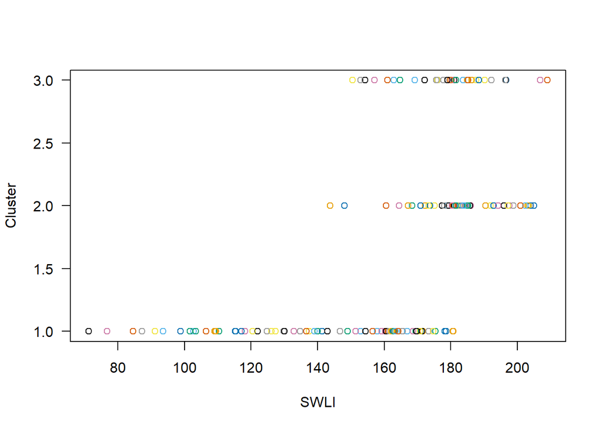

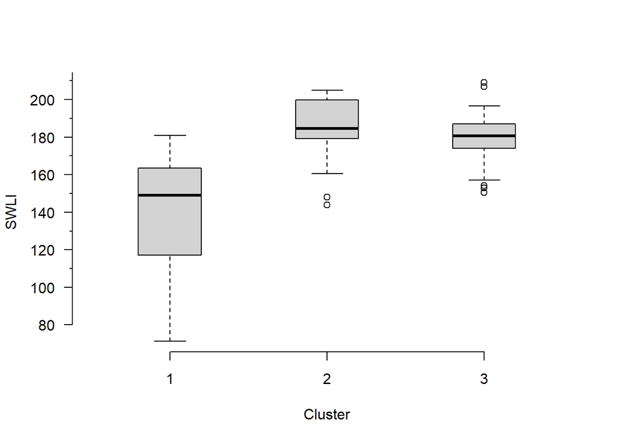

```r
cluster <- pamk(dis, krange = 3, criterion = "multiasw", critout = TRUE, metric = "euclidean")     # set to the chosen number of clusters
pt <- plot.pamk(k = 3, p2 = TRUE, p3 = TRUE, boxplot = TRUE)    # plot the clusters
```

Create a table of the data

```r
clustering <- as.data.frame(pt)
clustering
```

[output not shown]

### CCA & DCA

Run correlation analysis to understand the relationships.

```r
pcca <- cca(spec, env$SWLI)    # run CCA
w.cca <- round((pcca$CCA$eig / pcca$tot.chi) * 100, 2)   # extract the proportion of variance explained by the constrained axis (SWLI)
w.cca    # show the value
```

```
##  CCA1
## 10.73
```

```r
ns.dca <- decorana(veg=spec)    # run dca
ns.dca
```

```
##
## Call:
## decorana(veg = spec)
##
## Detrended correspondence analysis with 26 segments.
## Rescaling of axes with 4 iterations.
##
##                  DCA1  DCA2  DCA3  DCA4
## Eigenvalues     0.663 0.421 0.239 0.209
## Decorana values 0.670 0.488 0.218 0.127
## Axis lengths    4.575 4.141 2.747 1.821
```

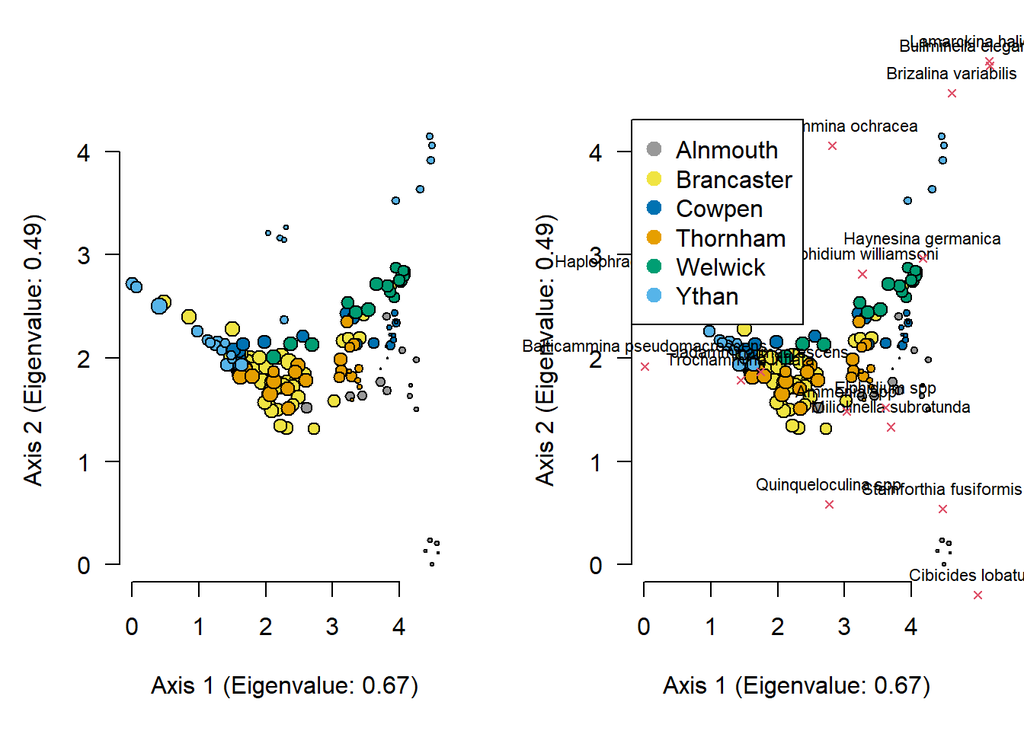

```r
plot.new()
plot_dca(origin = T)
```

### plot the foram species diagram using grahams function in ‘plot_foram_diagram.R’

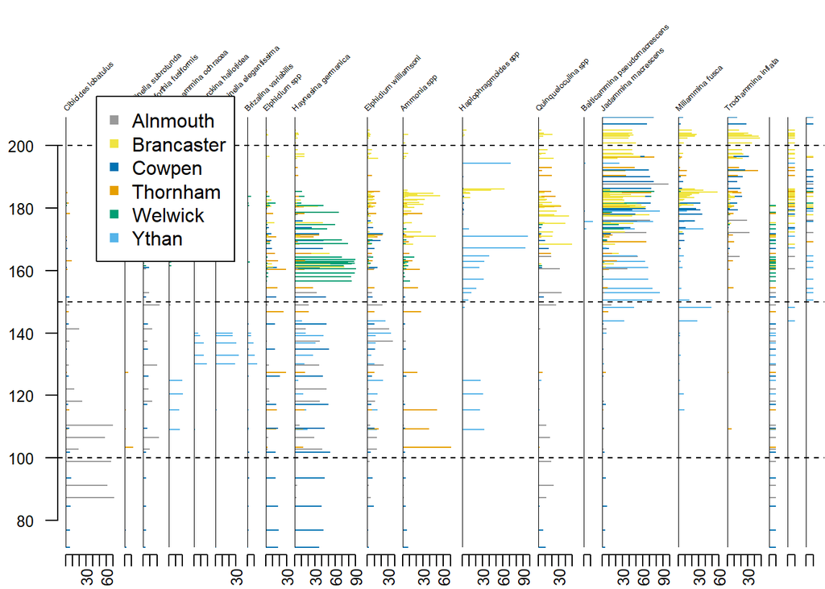

```r
plot_foram_diagram(data = training.set, min.species = 10, clusters = 3, method = "euclidean", plot_zones = TRUE,  zones = c(200, 150, 100), save_plot = FALSE)
```

## Perform the transfer functions

WA

```r
df.split (training.set, ts.sp)    # split the data
env$colour <- training_sets$cols$northsea[env$Site]

fit.wa <- WA(spec,env$SWLI, tolDW = T)    # run the WA transfer function
cv <- crossval(fit.wa, cv.method = "boot", nboot = 1000)   # perform cross-validation using bootstrapping
cv.wa.loso <- crossval(fit.wa, cv.method = "lgo", ngroups = env$Site)    # perform cross-validation using leave-one-site-out
test.wa <- as.data.frame(rand.t.test(cv))
```

```r
test.wa   # show results
```

|  | RMSE | R2 | Avg.Bias | Max.Bias | Skill | delta.RMSE | p |
| --- | --- | --- | --- | --- | --- | --- | --- |
| WA.inv | 18.73 | 0.6323 | -0.09752 | 62.58 | 63.23 | NA | NA |
| WA.cla | 22.77 | 0.6341 | -0.07631 | 50.64 | 46.70 | NA | NA |
| WA.inv.tol | 17.78 | 0.6736 | -0.38802 | 64.16 | 67.34 | -5.065 | 0 |
| WA.cla.tol | 20.88 | 0.6747 | -0.44251 | 54.91 | 56.14 | -8.284 | 0 |

WAPLS

```r
fit.wapls <- WAPLS(spec,env$SWLI)    # run the WAPLS transfer function
cv.loo <- crossval(fit.wapls, cv.method= "boot", nboot = 1000)   # perform cross-validation using bootstrapping
cv.loso <- crossval(fit.wapls, cv.method= "lgo", ngroups = env$Site)    # perform cross-validation using leave-one-site-out
test.wapls.loo <- as.data.frame(rand.t.test(cv.loo))
test.wapls.loso <- as.data.frame(rand.t.test(cv.loso))
```

```r
test.wapls.loo    # show results
```

|  | RMSE | R2 | Avg.Bias | Max.Bias | Skill | delta.RMSE | p |
| --- | --- | --- | --- | --- | --- | --- | --- |
| Comp01 | 18.75 | 0.6321 | -0.08132 | 62.79 | 63.21 | -38.468 | 0.001 |
| Comp02 | 17.84 | 0.6829 | 0.20545 | 62.27 | 68.17 | -4.868 | 0.015 |
| Comp03 | 17.37 | 0.7292 | 0.31083 | 53.83 | 72.77 | -2.598 | 0.024 |
| Comp04 | 17.64 | 0.7374 | 0.38502 | 48.44 | 73.53 | 1.525 | 0.256 |
| Comp05 | 18.48 | 0.7364 | 0.74865 | 43.88 | 73.08 | 4.785 | 0.674 |

LW

```r
fit.lw <- LWR(spec, env$SWLI, FUN=WAPLS, dist.method="sq.chord", k=50)    # run the locally weighted transfer function using WAPLS
cv.lw <- crossval(fit.lw, cv.method="boot", nboot = 100)    # cross validate the results using bootstrapping. For a full analysis it is recommended that this be increased to 1000
```

```r
cv.lw     # show the results
```

```
##
## Method : Locally Weighted Regression
## Call   : LWR(y = y, x = x, FUN = WAPLS, dist.method = "sq.chord", k = 50,
##     lean = TRUE)
## Distance           : sq.chord
## No. samples        : 166
## No. species        : 42
## No. local          : 50
##
## Performance:
##               RMSE      R2  Avg.Bias  Max.Bias  Skill
## Comp01       16.16  0.7201    0.3628     56.27  71.87
## Comp02       13.70  0.8013    1.5608     43.15  79.77
## Comp03       13.64  0.8011    1.1919     37.77  79.95
## Comp04       14.36  0.7790    0.6328     37.41  77.78
## Comp05       16.13  0.7297    0.6771     39.03  71.97
## Comp01_XVal  18.78  0.6202    0.5106     64.04  61.99
## Comp02_XVal  16.96  0.6905    0.0247     58.59  69.03
## Comp03_XVal  17.44  0.6735   -0.9706     52.41  67.24
## Comp04_XVal  18.65  0.6316   -0.9128     46.10  62.53
## Comp05_XVal  20.30  0.5791   -1.3159     41.74  55.60
```

Plot the residuals and predictions against the true value with 1 and 2 standard deviations shown using grahams functions in ‘plot_cross_validation.R’

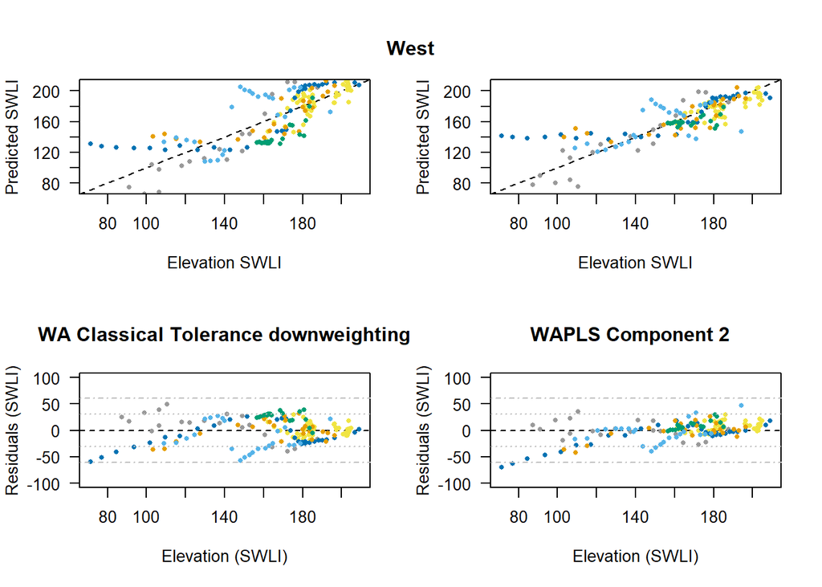

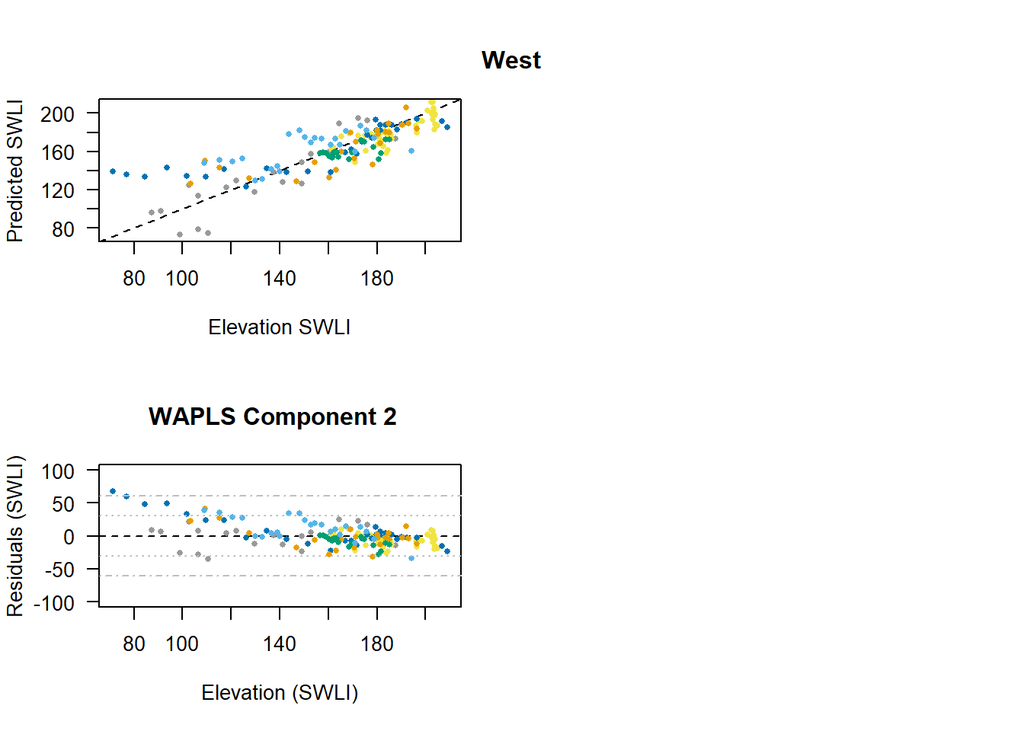

```r
plot_residuals(wa.mod = 2, zoom = TRUE)    # set to the desired wa deshrinking method. 2 = classical
plot_residuals_lw(model = 2, zoom = TRUE)
```

Compare cross-validation using leave-one-site-out using Grahams function in ‘loso.R’

```r
compare <- loso(wapls.mod, name)
```

```
##              LOO  LOSO       Site
## Alnmouth   16.08 25.31   Alnmouth
## Brancaster 10.86 19.90 Brancaster
## Cowpen     25.22 29.93     Cowpen
## Thornham   16.31 18.04   Thornham
## Welwick    11.88 27.05    Welwick
## Ythan      20.50 32.15      Ythan
```

Plot the bootstrapping and loso cross-validation

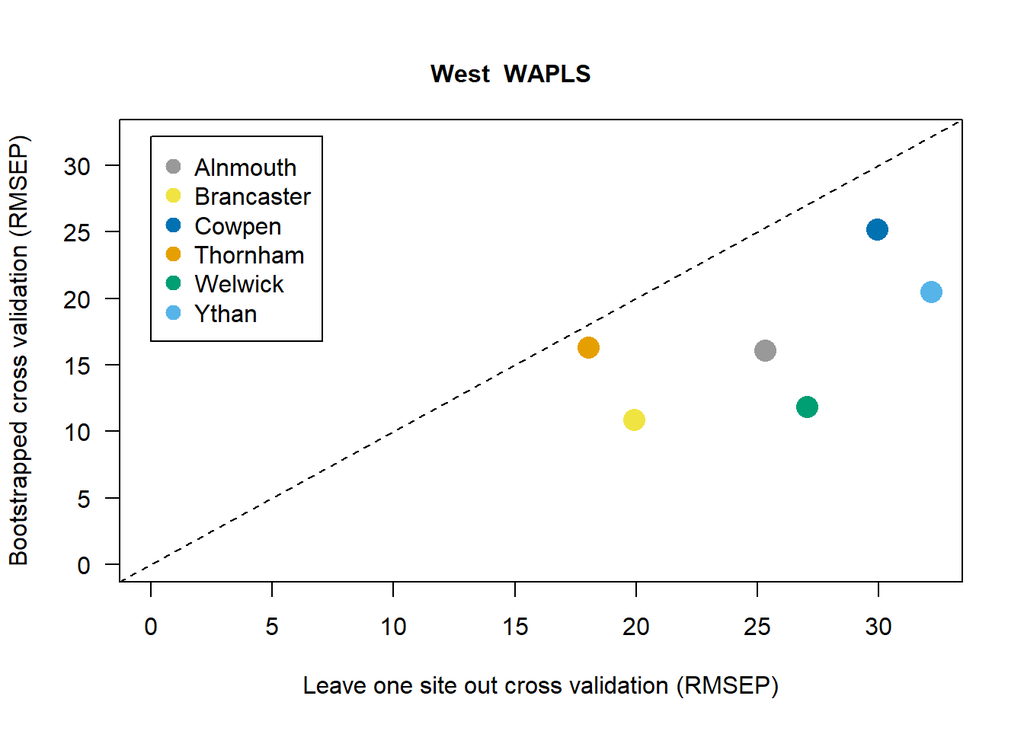

```r
plot_loso (zoom = TRUE, text = FALSE)
```

Save the results using Grahams function ‘saver.R’

```r
results <- saved(region = reg, method = paste("WAPLS-C", wapls.mod))
file_name <- paste("results/", "tf_", reg, ".csv", sep = "")
write.csv(results, file_name)
file_name <- paste("results/", "WAPLS-C", wapls.mod, "-compare-", reg, ".csv", sep = "")
write.csv(compare, file = file_name)
```

## Perform the reconstructions

Clean the core using grahams function in ‘cleaning.R’

```r
core_clean <- clean_core(core = core_data, s = 15, td = 1, rare = F, f = F)
core <- c.split (core_clean, s = 9) # split the core to species and environmental data.  15 is the last column of species data
```

Predict the SWLI for core samples using WA using grahams function in ‘Reconstructions.R’ Change the components to match the deshrinking method

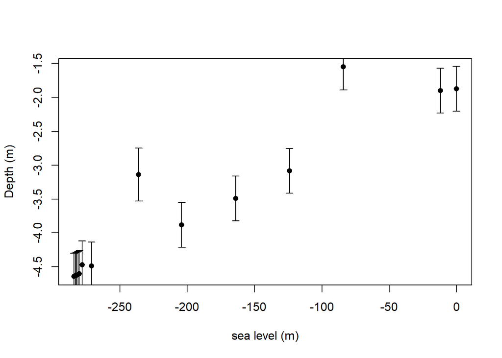

```r
prediction_wa <- reconstruct_core(core = core, tf = fit.wa, components = 4, species = 9, mhhw = 1.95, mtl = 0.3, mod = "wa.w",  plot = TRUE)
```

```r
core_clean <- cbind(core_clean, prediction_wa)    # add to the data
```

Predict the SWLI for core samples using WAPLS using grahams function in ‘Reconstructions.R’ Change the components to match the components

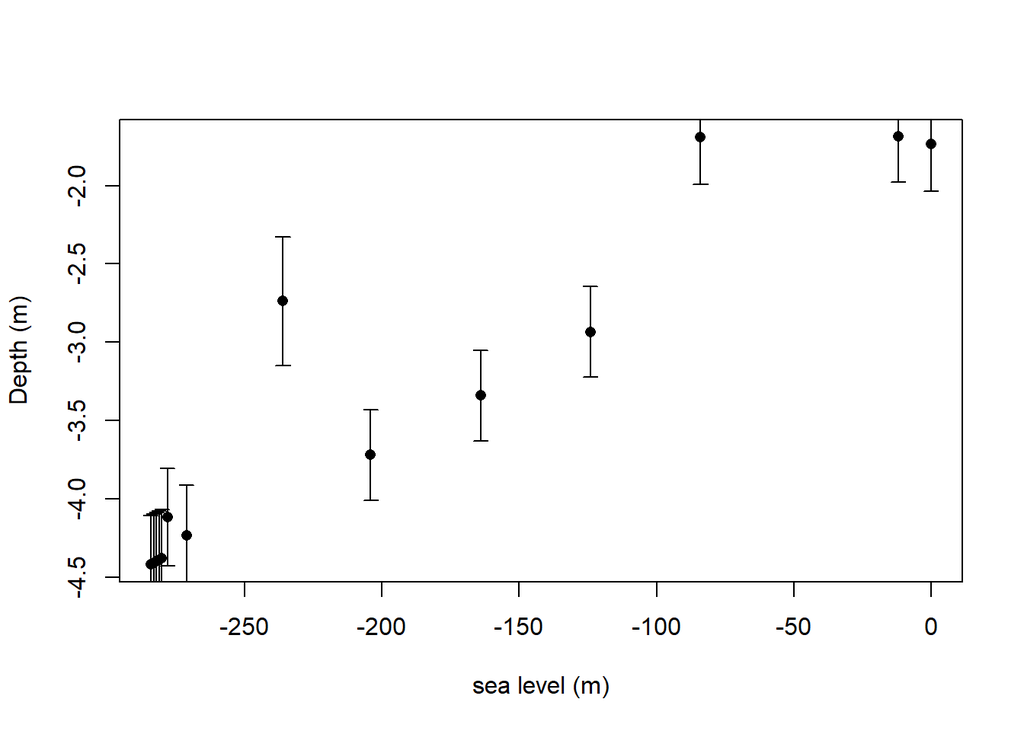

```r
prediction_wapls <- reconstruct_core(core = core, tf = fit.wapls, components = 2, species = 9, mhhw = 1.95, mtl = 0.3, mod = "wapls.w", plot = TRUE)
```

```r
core_clean <- cbind(core_clean, prediction_wapls)     # add to data for exporting and comparison
```

Predict the SWLI for core samples using Locally weighted - WAPLS

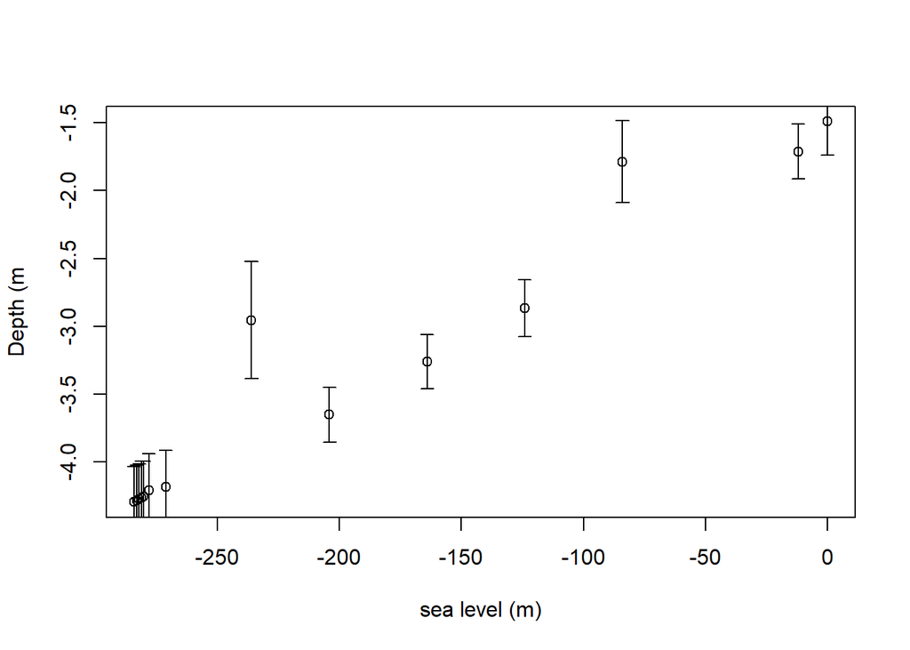

```r
prediction_lw <- run_lw_tf(n_analogues = 30, components = 2, tf = WAPLS, species = 9, mhhw = 1.95, mtl = 0.3, mod = "wa.w",  plot = TRUE, method = "sq.chord")
```

```r
core_clean <- cbind(core_clean, prediction_lw$sea_level)    # add to the data -->
```

Test the analogues. using MAT or goodness of fit using grahams functions in ‘test-mat.R’

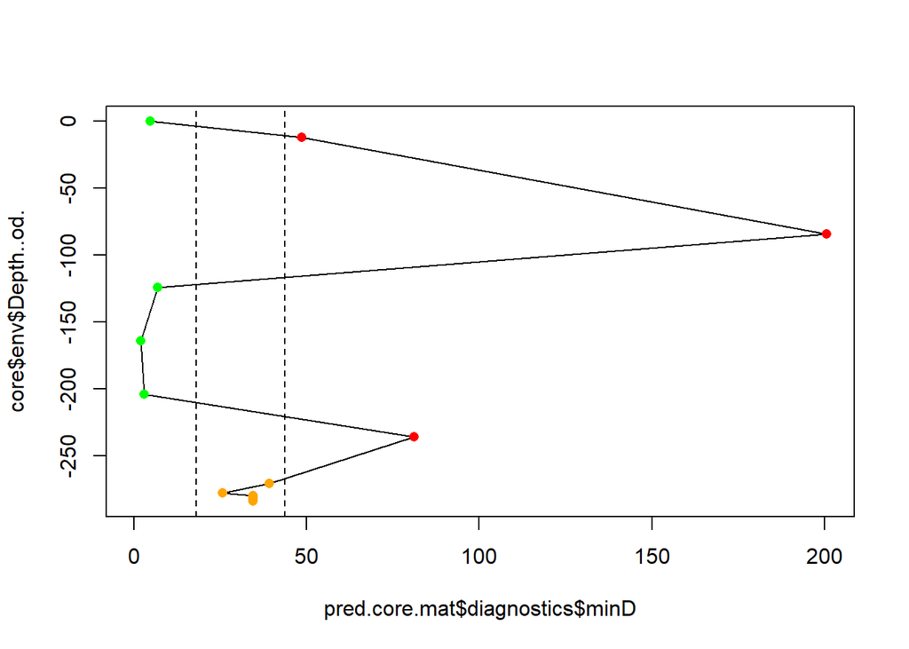

```r
mat <- run.mat(z = 50, d = "sq.chord", plot = TRUE)    # run the mat.
```

```r
core_clean <- cbind(core_clean, mat$mat)    # add to the data
# gof <- goodness_of_fit(plot = TRUE)    # run the goodness of fit
# core_clean <- cbind(core_clean, gof)    # add to the data
```

Save the results for each region

```r
file_name <- paste("results/", "reconstructions_", reg, ".csv", sep = "")
write.csv(core_clean, file_name)
```

Test whether the reconstructions are significant

```r
ralgh <- randomTF(spp = spec, env = env$SWLI, fos = core$spec, n = 99, fun = WAPLS, col = 2)
ralgh.wa <- randomTF(spp = spec, env = env$SWLI, fos = core$spec, n = 99, fun = WA, col = 2)
ralgh$sig    # show the data
```

```
##  env
## 0.82
```

```r
ralgh.wa$sig    # show the data
```

```
##  env
## 0.75
```